# A-SA25204160-11-03

SA25204160

2025-11-05

## Question

### 10.3

### 10.7

### Proof

证明在连续情况下，具有建议分布g(r|s)的M-H采样器的平稳分布是目标分布f(x).

## Answer

### 10.3

#### 10.3.1

首先实现两样本Cramér-von Mises检验统计量，使用公式(10.14)

#### 10.3.2

实现置换检验版本

#### 10.3.3

应用到例10.1和10.2的数据

```
## Cramér-von Mises置换检验结果:
```

```
## 检验统计量 = 4.2949
```

```
## p值 = 1
```

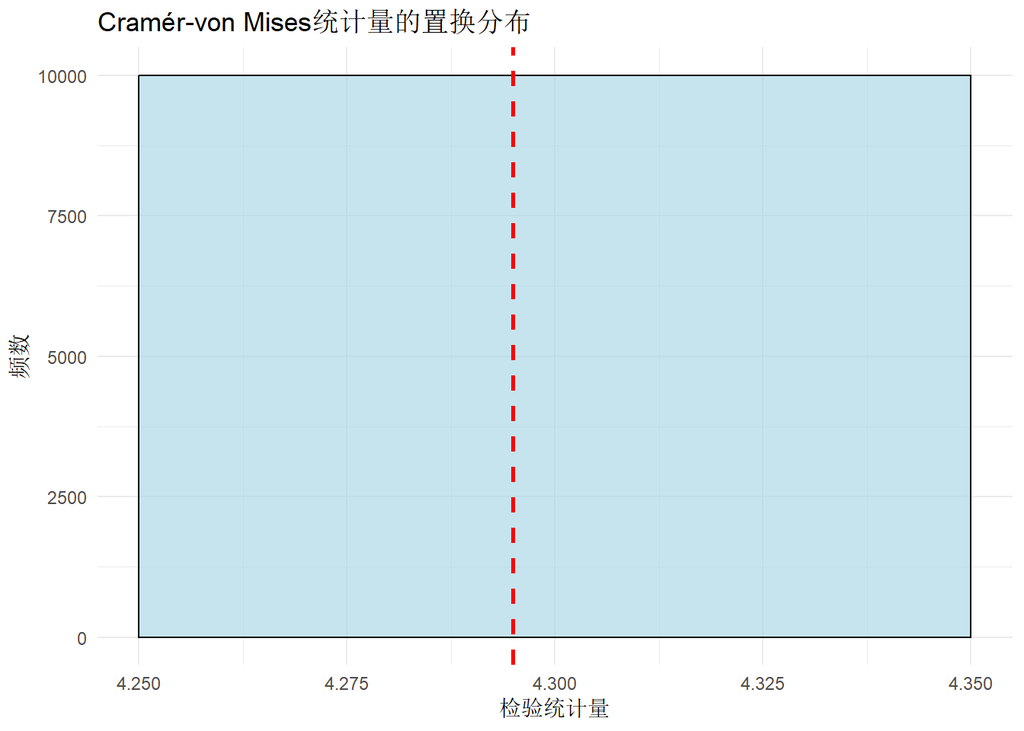

### 10.7

#### 10.7.1

首先实现Count Five检验的原始版本

#### 10.7.2

实现基于极端点最大数的置换方差检验

#### 10.7.3

重复例7.15的模拟，但使用置换检验

```
## 置换检验的Type I错误率模拟:
```

```
## n1 = 20, n2 = 30: Type I error rate = 0.014
```

```
## n1 = 20, n2 = 50: Type I error rate = 0.02
```

```
##
## 与原始Count Five检验比较:
```

```
## 原始方法 (n1=20, n2=30): 0.1064
```

```
## 置换方法 (n1=20, n2=30): 0.014
```

```
## 原始方法 (n1=20, n2=50): 0.2934
```

```
## 置换方法 (n1=20, n2=50): 0.02
```

#### 10.7.4

可视化结果比较

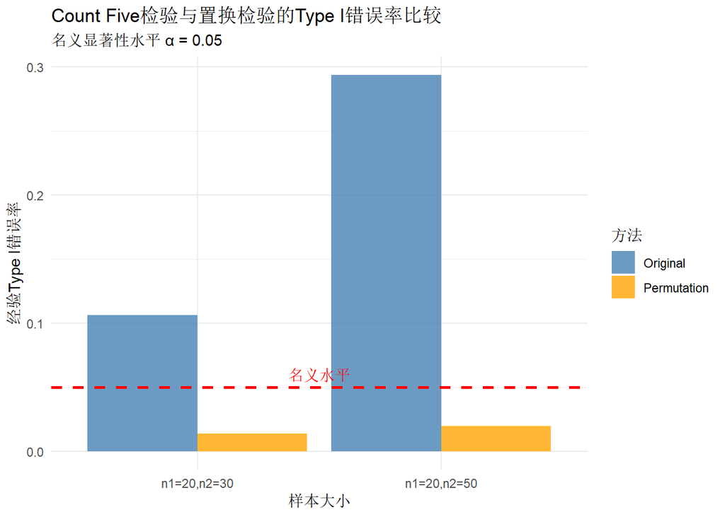

### Proof

因为是理论证明，所以没有代码，下面是证明过程。

设$f(x)$为目标分布，$g(r|s)$为建议分布。M-H算法的接受概率为：

$$\alpha(s \to r) = \min\left(1, \frac{f(r)g(s|r)}{f(s)g(r|s)}\right)$$

证明细致平衡条件成立

要证明$f(x)$是平稳分布，需要验证细致平衡条件：

$$f(s)P(s \to r) = f(r)P(r \to s)$$

其中转移概率$P(s \to r) = g(r|s)\alpha(s \to r)$

分情况证明细致平衡条件

当$\frac{f(r)g(s|r)}{f(s)g(r|s)} \geq 1$时

此时$\alpha(s \to r) = 1$，且$\alpha(r \to s) = \frac{f(s)g(r|s)}{f(r)g(s|r)}$

左边：
$$f(s)P(s \to r) = f(s)g(r|s) \cdot 1 = f(s)g(r|s)$$

右边：
$$f(r)P(r \to s) = f(r)g(s|r) \cdot \frac{f(s)g(r|s)}{f(r)g(s|r)} =
f(s)g(r|s)$$

$\therefore$ 左边 = 右边

继续证明另一种情况

当$\frac{f(r)g(s|r)}{f(s)g(r|s)} < 1$时

此时$\alpha(s \to r) = \frac{f(r)g(s|r)}{f(s)g(r|s)}$，且$\alpha(r \to s) = 1$

左边：
$$f(s)P(s \to r) = f(s)g(r|s) \cdot \frac{f(r)g(s|r)}{f(s)g(r|s)} =
f(r)g(s|r)$$

右边：
$$f(r)P(r \to s) = f(r)g(s|r) \cdot 1 = f(r)g(s|r)$$

$\therefore$ 左边 = 右边

结论

在两种情况下细致平衡条件均成立：

$$f(s)P(s \to r) = f(r)P(r \to s) \quad \forall s, r$$

因此，目标分布$f(x)$是M-H采样器的平稳分布。证毕。